# TO404_FinalProject

Brian Zhao

12/4/2020

# 1 TO 404 Final Project

## 1.1 Libraries

```r
library(dplyr)
```

```r
library(ggplot2)
library(geosphere)
library(data.table)
```

## 1.2 Read Data

```r
# Read Original CitiBike Data
sampleData <- read.csv("SampleCitiBike.csv")
# Create 1% Random Sample
sampleData_01 <- sample_frac(data, 0.01)
# Write to New CSV
write.csv(sampleData_01, 'sample_01_data.csv')
# Weather Data Manually Appended in new_MASTER_01_data.csv
```

```r
masterdata <- read.csv("new_MASTER_01_data.csv")
```

## 1.3 Clean Data

```r
# Explore Data
str(masterdata)
```

```
## 'data.frame':    205517 obs. of  48 variables:
##  $ X                      : int  1 2 3 4 5 6 7 8 9 10 ...
##  $ tripduration           : int  110 1067 325 552 282 1150 178 777 423 144 ...
##  $ start.station.id       : chr  "3283" "468" "305" "486" ...
##  $ start.station.name     : chr  "W 89 St & Columbus Ave" "Broadway & W 56 St" "E 58 St & 3 Ave" "Broadway & W 29 St" ...
##  $ start.station.latitude : num  40.8 40.8 40.8 40.7 40.7 ...
##  $ start.station.longitude: num  -74 -74 -74 -74 -74 ...
##  $ end.station.id         : chr  "3170" "3641" "359" "402" ...
##  $ end.station.name       : chr  "W 84 St & Columbus Ave" "Broadway & W 25 St" "E 47 St & Park Ave" "Broadway & E 22 St" ...
##  $ end.station.latitude   : num  40.8 40.7 40.8 40.7 40.7 ...
##  $ end.station.longitude  : num  -74 -74 -74 -74 -74 ...
##  $ bikeid                 : int  38891 38269 14654 15101 32868 30584 32492 30258 36783 36111 ...
##  $ usertype               : chr  "Subscriber" "Subscriber" "Subscriber" "Subscriber" ...
##  $ birth.year             : int  1989 1965 1990 1977 1996 1988 1954 1989 1977 1961 ...
##  $ gender                 : int  1 1 1 1 1 1 1 1 1 1 ...
```

[output cut: 34 more lines]

```r
summary(masterdata)
```

```
##        X           tripduration       start.station.id   start.station.name
##  Min.   :     1   Min.   :     61.0   Length:205517      Length:205517
##  1st Qu.: 51380   1st Qu.:    363.0   Class :character   Class :character
##  Median :102759   Median :    616.0   Mode  :character   Mode  :character
##  Mean   :102759   Mean   :    992.7
##  3rd Qu.:154138   3rd Qu.:   1081.0
##  Max.   :205517   Max.   :2678003.0
##
##  start.station.latitude start.station.longitude end.station.id
##  Min.   :40.66          Min.   :-74.03          Length:205517
##  1st Qu.:40.72          1st Qu.:-74.00          Class :character
##  Median :40.74          Median :-73.99          Mode  :character
##  Mean   :40.74          Mean   :-73.98
##  3rd Qu.:40.76          3rd Qu.:-73.97
##  Max.   :40.86          Max.   :-73.89
##
##  end.station.name   end.station.latitude end.station.longitude     bikeid
##  Length:205517      Min.   :40.66        Min.   :-74.05        Min.   :14529
##  Class :character   1st Qu.:40.72        1st Qu.:-74.00        1st Qu.:25323
##  Mode  :character   Median :40.74        Median :-73.99        Median :30947
##                     Mean   :40.74        Mean   :-73.98        Mean   :29669
##                     3rd Qu.:40.76        3rd Qu.:-73.97        3rd Qu.:35053
##                     Max.   :40.86        Max.   :-73.89        Max.   :42046
##
##    usertype           birth.year       gender           AWND
##  Length:205517      Min.   :1886   Min.   :0.000   Min.   : 1.120
##  Class :character   1st Qu.:1969   1st Qu.:1.000   1st Qu.: 2.910
##  Mode  :character   Median :1983   Median :1.000   Median : 4.030
##                     Mean   :1980   Mean   :1.164   Mean   : 4.385
##                     3rd Qu.:1990   3rd Qu.:1.000   3rd Qu.: 5.140
##                     Max.   :2003   Max.   :2.000   Max.   :12.750
##                                                    NA's   :22301
##  AWND_ATTRIBUTES         PRCP       PRCP_ATTRIBUTES         SNOW
##  Length:205517      Min.   :0.000   Length:205517      Min.   :0.000
##  Class :character   1st Qu.:0.000   Class :character   1st Qu.:0.000
##  Mode  :character   Median :0.000   Mode  :character   Median :0.000
##                     Mean   :0.106                      Mean   :0.019
##                     3rd Qu.:0.040                      3rd Qu.:0.000
##                     Max.   :1.830                      Max.   :4.000
##                                                        NA's   :545
```

[output cut: 49 more lines]

```
##  Length:205517      Min.   :1        Length:205517      Length:205517
##  Class :character   1st Qu.:1        Class :character   Class :character
##  Mode  :character   Median :1        Mode  :character   Mode  :character
##                     Mean   :1
##                     3rd Qu.:1
##                     Max.   :1
##                     NA's   :172801
##  newStopTime
##  Length:205517
##  Class :character
##  Mode  :character
##
##
##
##
```

```r
# Remove Identifier Column
masterdata$X <- NULL

# Assign Factors
masterdata$bikeid <- as.factor(masterdata$bikeid)
masterdata$gender <- as.factor(masterdata$gender)
masterdata$gender <- as.factor(ifelse(masterdata$gender == "0", "Unknown", ifelse(masterdata$gender == "1", "Male", "Female")))

# Distance
masterstart <- as.data.frame(matrix(nrow = 205517, ncol = 0))
masterstart$startlong <- as.numeric(masterdata$start.station.longitude)
masterstart$startlat <- as.numeric(masterdata$start.station.latitude)

masterend <- as.data.frame(matrix(nrow = 205517, ncol = 0))
masterend$endlong <- masterdata$end.station.longitude
masterend$endlat <- masterdata$end.station.latitude

masterdata$distanceH <- distHaversine(masterstart, masterend, r=6378137)

# Speed
masterdata$speedMetersperMin <- masterdata$distanceH / masterdata$tripduration

# Date
masterdata$newStartTime = as.POSIXct(strptime(masterdata$newStartTime, "%Y-%m-%d %H:%M:%S"))
masterdata$newStopTime = as.POSIXct(strptime(masterdata$newStopTime, "%Y-%m-%d %H:%M:%S"))
masterdata$startDate <- as.Date(masterdata$newStartTime)

# Snow
masterdata$roundedSNOW <- floor(masterdata$SNOW)

# Check Data
str(masterdata)
```

```
## 'data.frame':    205517 obs. of  51 variables:
##  $ tripduration           : int  110 1067 325 552 282 1150 178 777 423 144 ...
##  $ start.station.id       : chr  "3283" "468" "305" "486" ...
##  $ start.station.name     : chr  "W 89 St & Columbus Ave" "Broadway & W 56 St" "E 58 St & 3 Ave" "Broadway & W 29 St" ...
##  $ start.station.latitude : num  40.8 40.8 40.8 40.7 40.7 ...
##  $ start.station.longitude: num  -74 -74 -74 -74 -74 ...
##  $ end.station.id         : chr  "3170" "3641" "359" "402" ...
##  $ end.station.name       : chr  "W 84 St & Columbus Ave" "Broadway & W 25 St" "E 47 St & Park Ave" "Broadway & E 22 St" ...
##  $ end.station.latitude   : num  40.8 40.7 40.8 40.7 40.7 ...
##  $ end.station.longitude  : num  -74 -74 -74 -74 -74 ...
##  $ bikeid                 : Factor w/ 19094 levels "14529","14530",..: 16053 15465 97 422 11882 9967 11539 9673 14577 14187 ...
##  $ usertype               : chr  "Subscriber" "Subscriber" "Subscriber" "Subscriber" ...
##  $ birth.year             : int  1989 1965 1990 1977 1996 1988 1954 1989 1977 1961 ...
##  $ gender                 : Factor w/ 3 levels "Female","Male",..: 2 2 2 2 2 2 2 2 2 2 ...
##  $ AWND                   : num  3.36 5.37 2.91 1.79 2.91 2.91 2.68 2.91 7.83 4.47 ...
```

[output cut: 37 more lines]

```r
summary(masterdata)
```

```
##   tripduration       start.station.id   start.station.name
##  Min.   :     61.0   Length:205517      Length:205517
##  1st Qu.:    363.0   Class :character   Class :character
##  Median :    616.0   Mode  :character   Mode  :character
##  Mean   :    992.7
##  3rd Qu.:   1081.0
##  Max.   :2678003.0
##
##  start.station.latitude start.station.longitude end.station.id
##  Min.   :40.66          Min.   :-74.03          Length:205517
##  1st Qu.:40.72          1st Qu.:-74.00          Class :character
##  Median :40.74          Median :-73.99          Mode  :character
##  Mean   :40.74          Mean   :-73.98
##  3rd Qu.:40.76          3rd Qu.:-73.97
##  Max.   :40.86          Max.   :-73.89
##
##  end.station.name   end.station.latitude end.station.longitude     bikeid
##  Length:205517      Min.   :40.66        Min.   :-74.05        35306  :    44
##  Class :character   1st Qu.:40.72        1st Qu.:-74.00        34019  :    41
##  Mode  :character   Median :40.74        Median :-73.99        34958  :    41
##                     Mean   :40.74        Mean   :-73.98        35029  :    41
##                     3rd Qu.:40.76        3rd Qu.:-73.97        35324  :    41
##                     Max.   :40.86        Max.   :-73.89        33885  :    40
##                                                                (Other):205269
##    usertype           birth.year       gender            AWND
##  Length:205517      Min.   :1886   Female : 49419   Min.   : 1.120
##  Class :character   1st Qu.:1969   Male   :140370   1st Qu.: 2.910
##  Mode  :character   Median :1983   Unknown: 15728   Median : 4.030
##                     Mean   :1980                    Mean   : 4.385
##                     3rd Qu.:1990                    3rd Qu.: 5.140
##                     Max.   :2003                    Max.   :12.750
##                                                     NA's   :22301
##  AWND_ATTRIBUTES         PRCP       PRCP_ATTRIBUTES         SNOW
##  Length:205517      Min.   :0.000   Length:205517      Min.   :0.000
##  Class :character   1st Qu.:0.000   Class :character   1st Qu.:0.000
##  Mode  :character   Median :0.000   Mode  :character   Median :0.000
##                     Mean   :0.106                      Mean   :0.019
##                     3rd Qu.:0.040                      3rd Qu.:0.000
##                     Max.   :1.830                      Max.   :4.000
##                                                        NA's   :545
```

[output cut: 57 more lines]

```
##  Min.   :2019-01-01 00:35:03   Min.   :2019-01-01 00:38:10   Min.   :    0.0
##  1st Qu.:2019-05-03 06:30:28   1st Qu.:2019-05-03 06:49:10   1st Qu.:  825.9
##  Median :2019-07-18 16:48:45   Median :2019-07-18 16:59:56   Median : 1375.9
##  Mean   :2019-07-12 13:31:09   Mean   :2019-07-12 13:47:42   Mean   : 1779.9
##  3rd Qu.:2019-09-23 18:04:58   3rd Qu.:2019-09-23 18:18:30   3rd Qu.: 2305.2
##  Max.   :2019-12-31 23:33:21   Max.   :2020-01-02 09:26:42   Max.   :13812.2
##
##  speedMetersperMin   startDate           roundedSNOW
##  Min.   :0.000     Min.   :2019-01-01   Min.   :0.0000
##  1st Qu.:1.946     1st Qu.:2019-05-03   1st Qu.:0.0000
##  Median :2.504     Median :2019-07-18   Median :0.0000
##  Mean   :2.441     Mean   :2019-07-12   Mean   :0.0138
##  3rd Qu.:3.033     3rd Qu.:2019-09-23   3rd Qu.:0.0000
##  Max.   :8.356     Max.   :2020-01-01   Max.   :4.0000
##                                         NA's   :545
```

# 2 Weather

## 2.1 Snow

*Effects of Snow on:*

- Ride Distance (Customer vs. Subscriber)

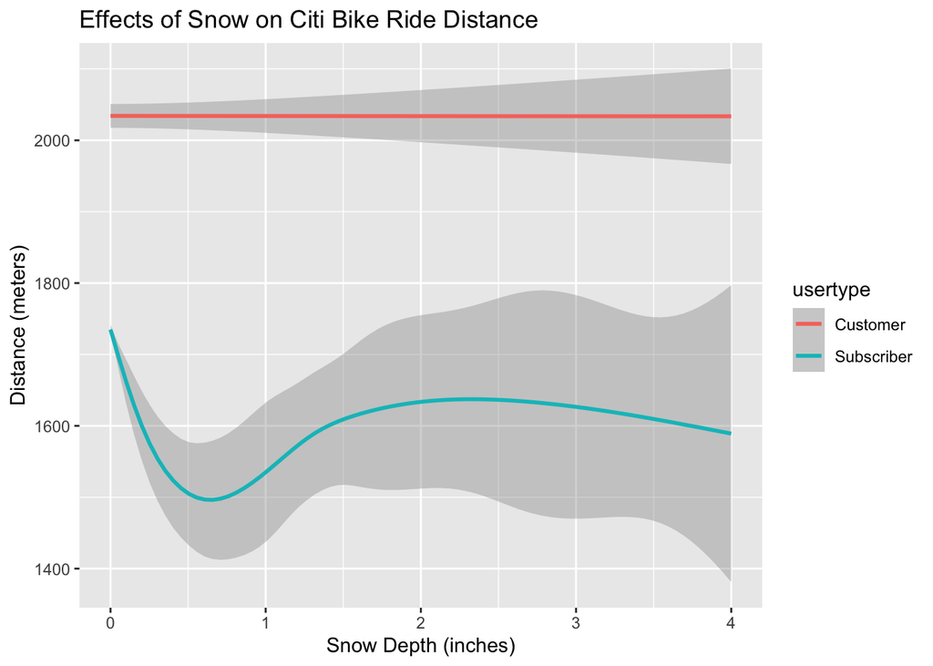

```r
ggplot(data=masterdata[masterdata$distanceH < 10000,], aes(x=SNOW, y=distanceH, colour=usertype)) + geom_smooth() + labs(title = "Effects of Snow on Citi Bike Ride Distance", x = "Snow Depth (inches)", y = "Distance (meters)")
```

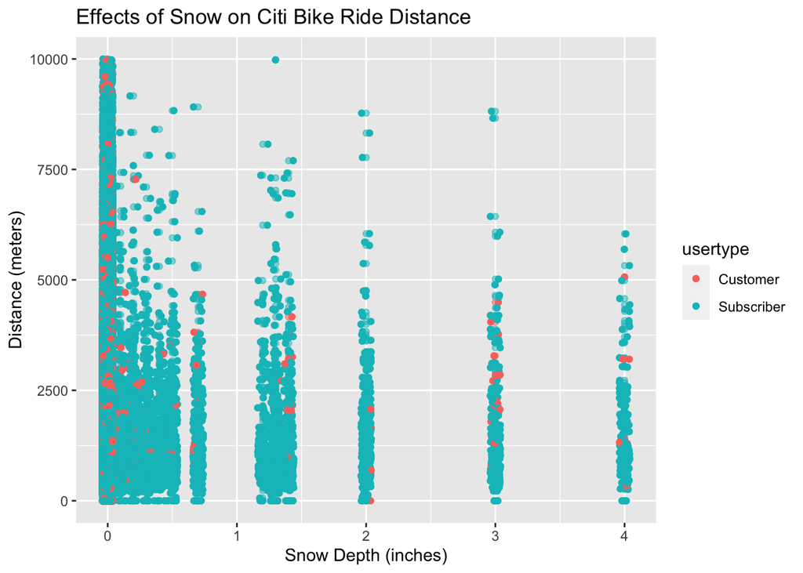

```r
ggplot(data=masterdata[masterdata$distanceH < 10000,], aes(x=SNOW, y=distanceH, colour=usertype)) + geom_point(alpha = 0.5) + geom_jitter() + labs(title = "Effects of Snow on Citi Bike Ride Distance", x = "Snow Depth (inches)", y = "Distance (meters)")
```

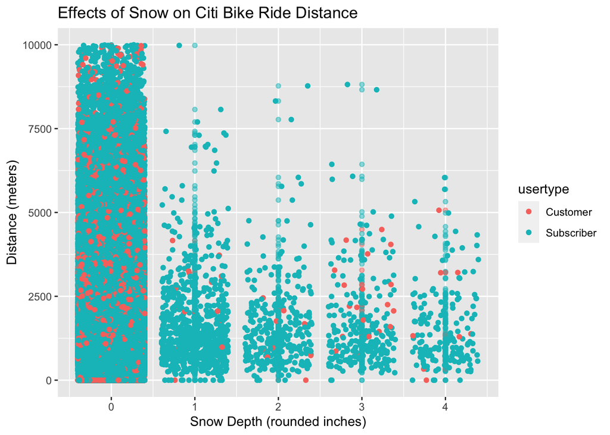

```r
ggplot(data=masterdata[masterdata$distanceH < 10000,], aes(x=roundedSNOW, y=distanceH, colour=usertype)) + geom_point(alpha = 0.5) + geom_jitter() + labs(title = "Effects of Snow on Citi Bike Ride Distance", x = "Snow Depth (rounded inches)", y = "Distance (meters)")
```

We can see the trend that customers generally ride a consistent distance regardless of snow, while subscribers tend to travel shorter distances when there is snow. This is likely due to the fact that subscribers or frequent users are more likely to be locals to NYC and use other forms of transportation instead (i.e. subway).

However, if we also factor in the amount of rides that are happening, we can see that subscribers make up a larger percentage of the total rides compared to customers whenever there is snow on the ground. Subscribers who are more likely to use a CitiBike than a regular customer in the snow (but will also ride a shorter distance).

- Ride Duration

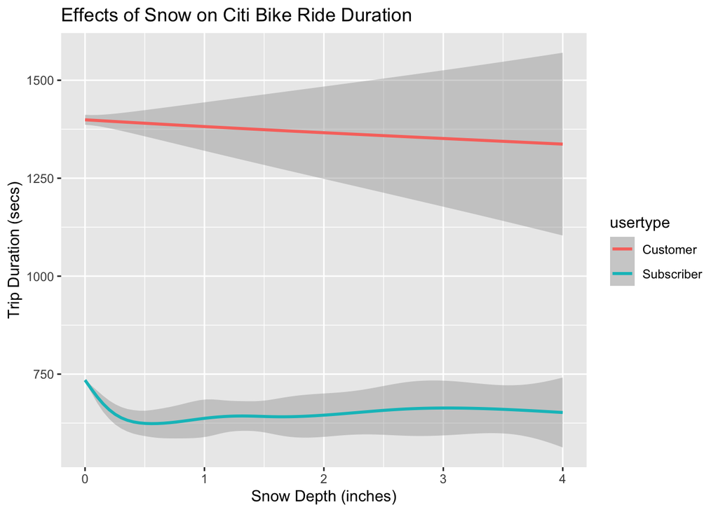

```r
ggplot(data=masterdata[masterdata$tripduration < 10000,], aes(x=SNOW, y=tripduration, colour=usertype)) + geom_smooth() + labs(title = "Effects of Snow on Citi Bike Ride Duration", x = "Snow Depth (inches)", y = "Trip Duration (secs)")
```

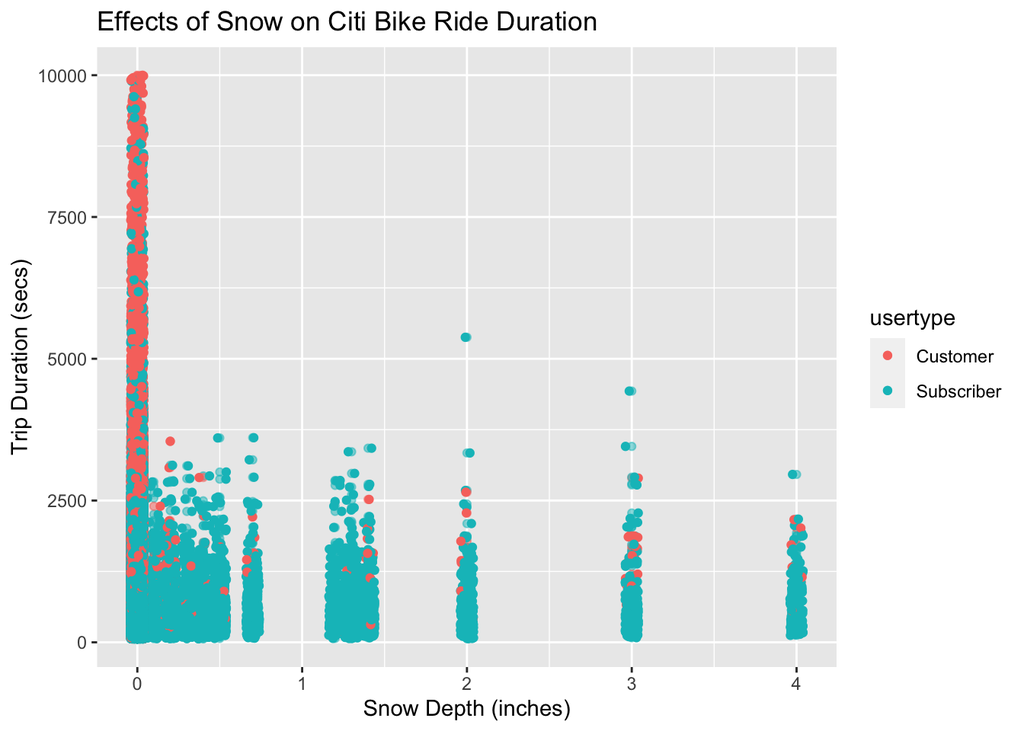

```r
ggplot(data=masterdata[masterdata$tripduration < 10000,], aes(x=SNOW, y=tripduration, colour=usertype)) + geom_point(alpha = 0.5) + geom_jitter() + labs(title = "Effects of Snow on Citi Bike Ride Duration", x = "Snow Depth (inches)", y = "Trip Duration (secs)")
```

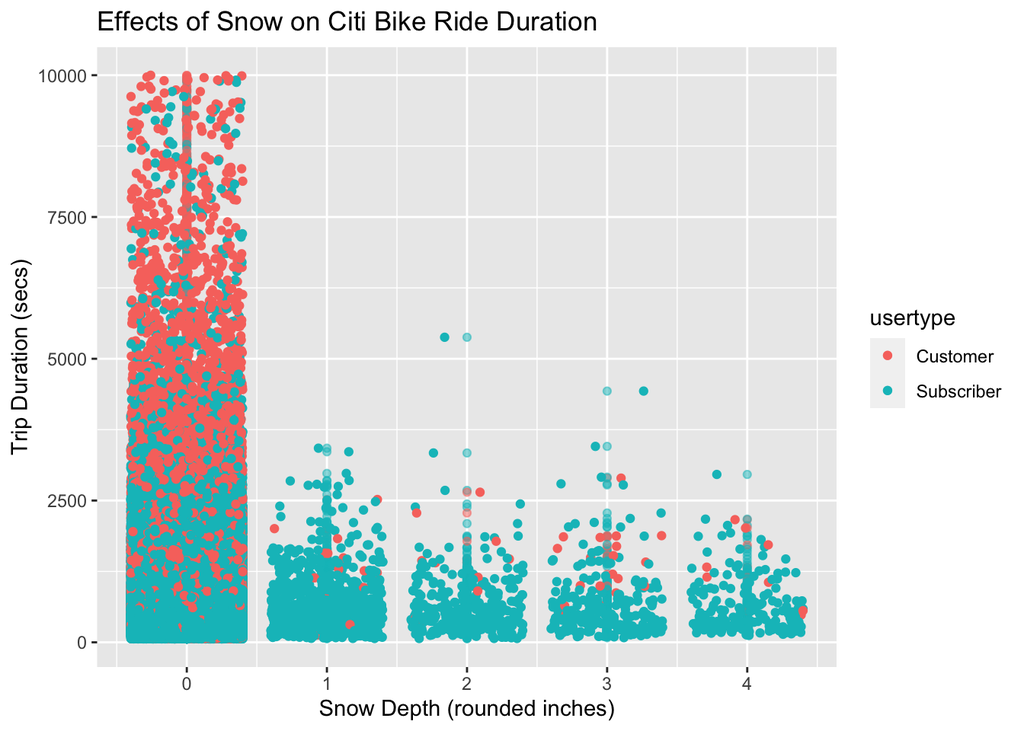

```r
ggplot(data=masterdata[masterdata$tripduration < 10000,], aes(x=roundedSNOW, y=tripduration, colour=usertype)) + geom_point(alpha = 0.5) + geom_jitter() + labs(title = "Effects of Snow on Citi Bike Ride Duration", x = "Snow Depth (rounded inches)", y = "Trip Duration (secs)")
```

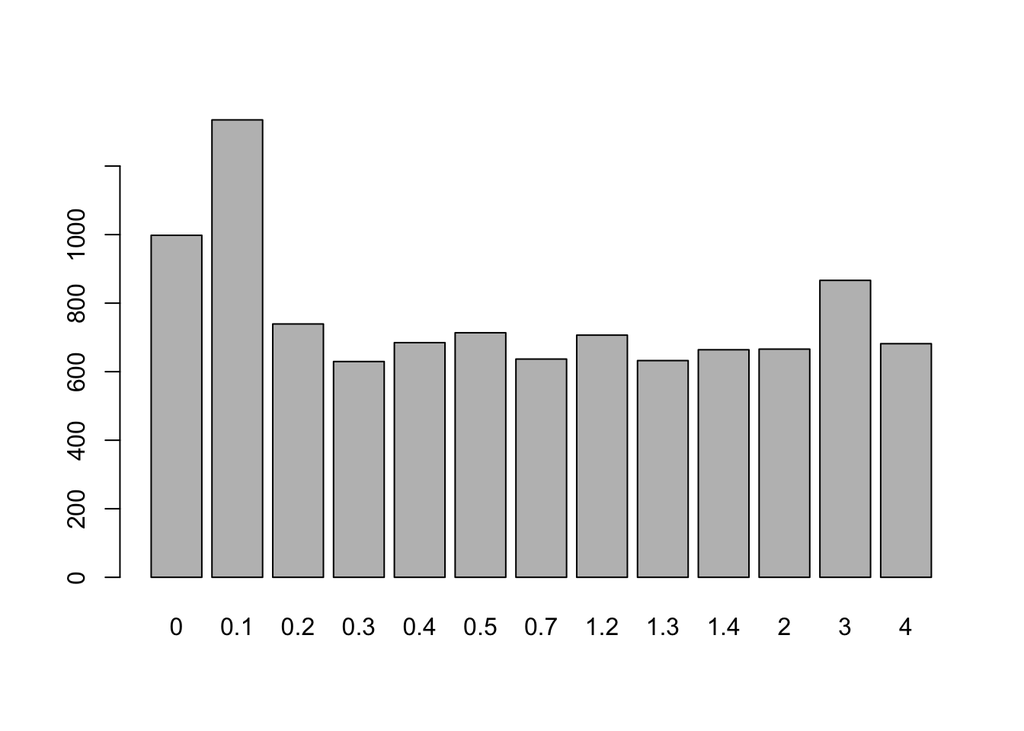

```r
totalRides <- tapply(masterdata$tripduration, masterdata$SNOW, mean, na.rm = TRUE)
barplot(totalRides)
```

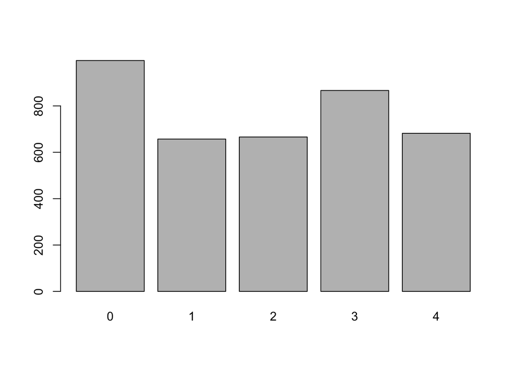

```r
totalRides <- tapply(masterdata$tripduration, masterdata$roundedSNOW, mean, na.rm = TRUE)
barplot(totalRides)
```

A potential solution to increase business would be to increase incentives for non-subscribers to ride when their is snow (is pricing a concern for them?) >> risk: liability?

- Total Rides

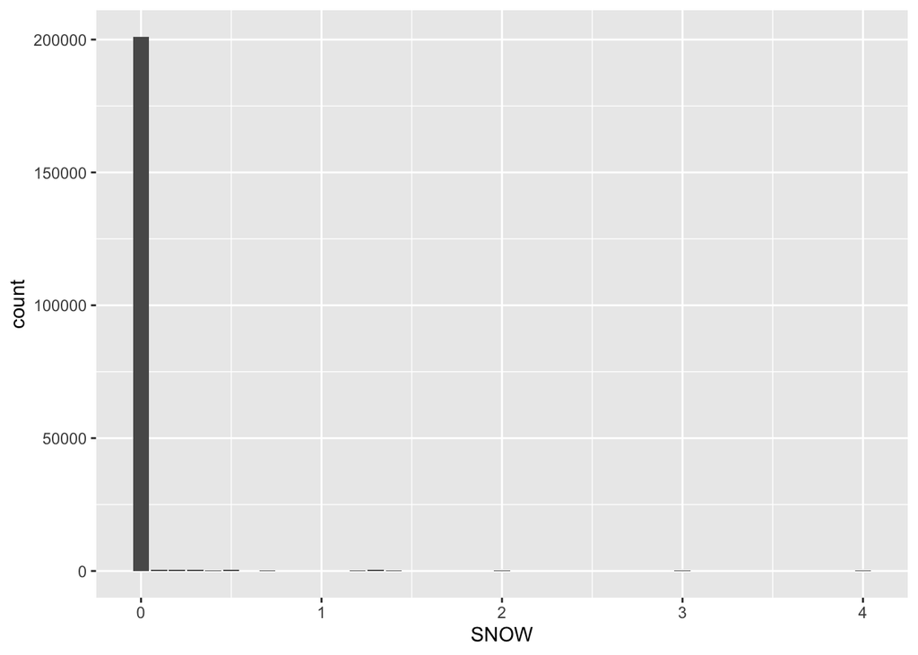

```r
# Count - Raw Data
ggplot(data=masterdata, aes(x=SNOW)) + geom_bar()
```

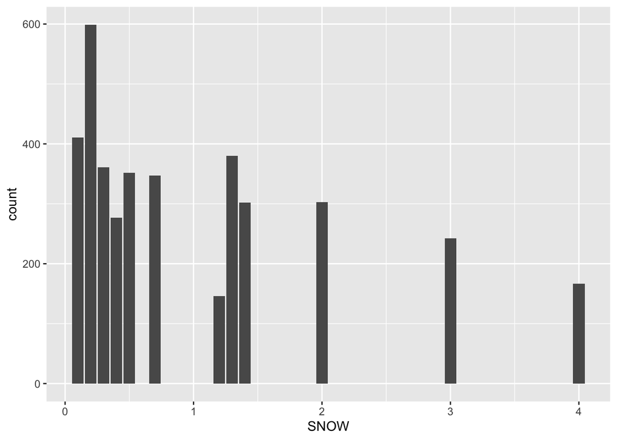

```r
ggplot(data=masterdata[masterdata$SNOW > 0, ], aes(x=SNOW)) + geom_bar()
```

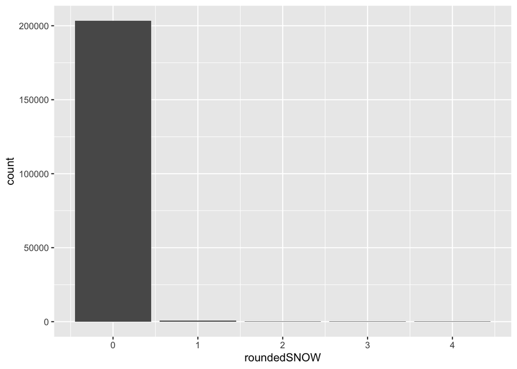

```r
# Count - Rounded Values
ggplot(data=masterdata, aes(x=roundedSNOW)) + geom_bar()
```

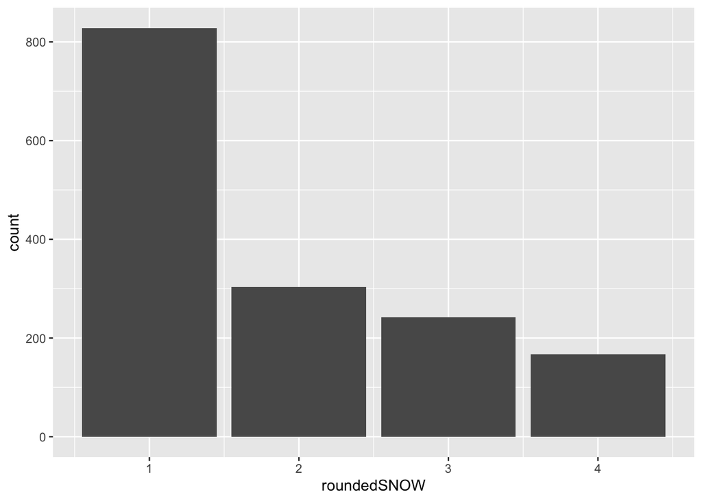

```r
ggplot(data=masterdata[masterdata$roundedSNOW > 0, ], aes(x=roundedSNOW)) + geom_bar()
```

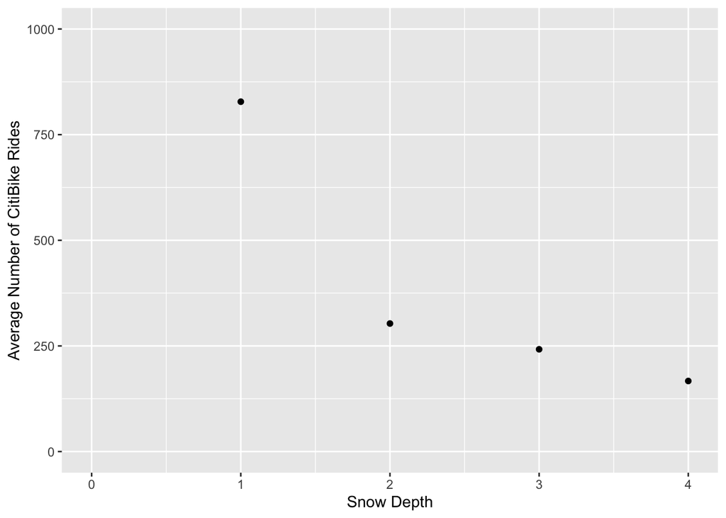

```r
# Average - Rounded Values
masterdata %>%
  group_by(roundedSNOW) %>%
  summarise(
    numRides = mean(n())
  ) %>%
  ggplot(aes(x = roundedSNOW, y = numRides)) + geom_point() + ylim(0,1000) + labs(x = "Snow Depth", y = "Average Number of CitiBike Rides")
```

- Demographics (Female vs. Male, Age)

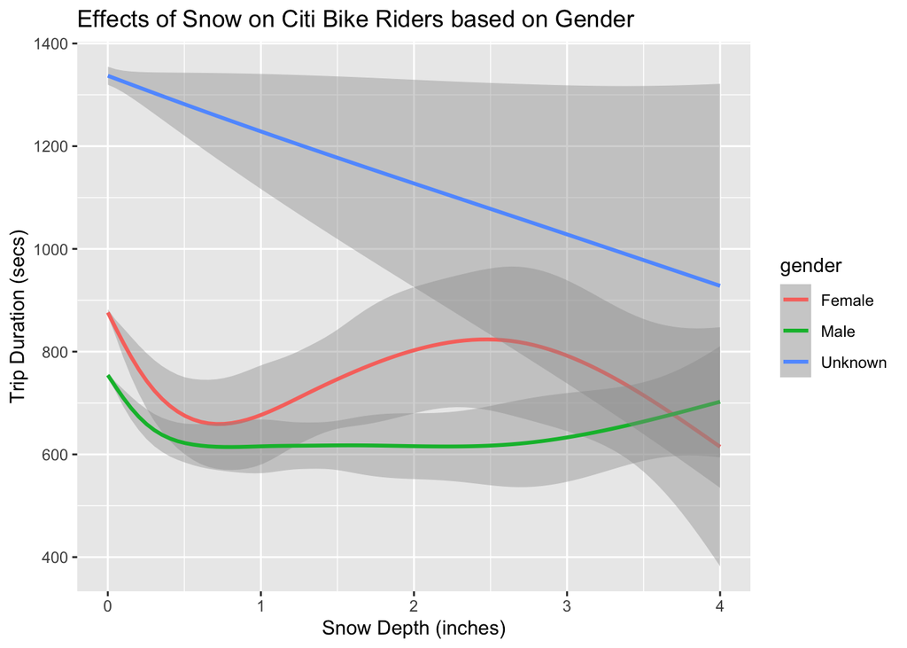

```r
ggplot(data=masterdata[masterdata$tripduration < 10000,], aes(x=SNOW, y=tripduration, colour=gender)) + geom_smooth() + labs(title = "Effects of Snow on Citi Bike Riders based on Gender", x = "Snow Depth (inches)", y = "Trip Duration (secs)")
```

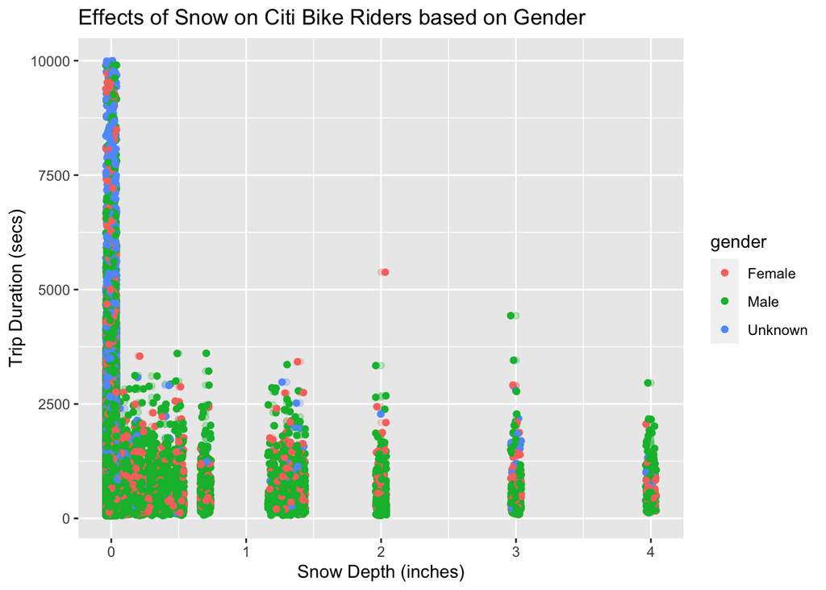

```r
ggplot(data=masterdata[masterdata$tripduration < 10000,], aes(x=SNOW, y=tripduration, colour=gender)) + geom_point(alpha = 0.25) + geom_jitter() + labs(title = "Effects of Snow on Citi Bike Riders based on Gender", x = "Snow Depth (inches)", y = "Trip Duration (secs)")
```

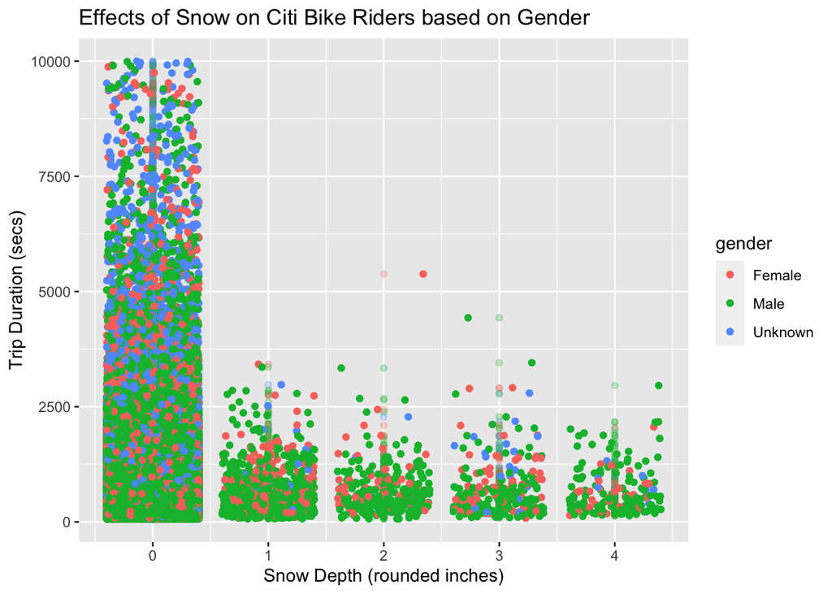

```r
ggplot(data=masterdata[masterdata$tripduration < 10000,], aes(x=roundedSNOW, y=tripduration, colour=gender)) + geom_point(alpha = 0.25) + geom_jitter() + labs(title = "Effects of Snow on Citi Bike Riders based on Gender", x = "Snow Depth (rounded inches)", y = "Trip Duration (secs)")
```

It seems that males are more likely to continue riding CitiBikes when there is snow on the ground than Females or Unknowns (which is expected as Unknowns fall largely in the non-subscriber category), but the difference is minimal.

- Speed

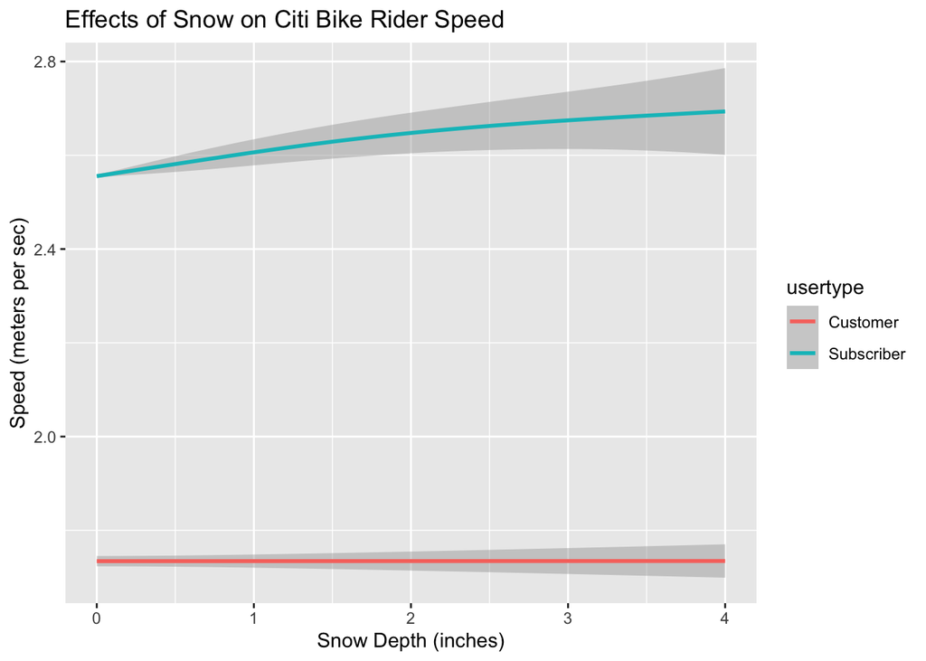

```r
ggplot(data=masterdata, aes(x=SNOW, y=speedMetersperMin, colour=usertype)) + geom_smooth() + labs(title = "Effects of Snow on Citi Bike Rider Speed", x = "Snow Depth (inches)", y = "Speed (meters per sec)")
```

Subscribers are trying to get from point A to point B and actually go faster with more snow (likely to get out of the cold and we can assume NYC streets are well plowed despite indicated snow depth)